# Informe técnico de calidad de archivos estadísticos

Ejercicio educativo | INEC | R y Quarto

Autor/a

Capacitación técnica en calidad de datos

Fecha de publicación

10/11/2026

# 1 Resumen ejecutivo

Este informe es una **simulación académica** de control de calidad de archivos estadísticos. El período de referencia declarado es **2026-10** y el conjunto contiene **1.500 registros**. El documento compara **datos originales** con una **propuesta de normalización pendiente de autorización**, no dos levantamientos oficiales.

Se registraron **86 eventos de alerta** en los controles seleccionados de consistencia e integridad, que involucraron a **83 filas diferentes** (5.53 % del archivo). Una misma fila puede activar más de una regla, por lo que no se deben equiparar eventos y personas afectadas.

# 2 Procedencia y alcance

- Archivo fuente: `personas_encuesta_sintetica_2026_10.csv`.
- Unidad de análisis: registro de persona en un archivo ficticio.
- Reglas: controles didácticos de completitud, validez, unicidad e integridad.
- Estado de la versión comparativa: **propuesta no autorizada**.
- Denominadores: explícitos para cada indicador; no promediar porcentajes con bases diferentes.

## 2.1 Inspección del período declarado

Valores encontrados en periodo_referencia

| periodo_referencia | filas | formato_aaaa_mm | interpretacion |
| --- | --- | --- | --- |
| 2026-10 | 1492 | TRUE | Formato esperado |
| 2026/10 | 8 | FALSE | Revisar formato |

Los textos que no cumplen el patrón `AAAA-MM` se presentan como problemas de formato; por ejemplo, `2026/10` no representa un período estadístico adicional.

# 3 Indicadores de calidad

## 3.1 Tabla comparativa de indicadores

Indicadores: línea base y escenario de normalización

| Indicador | Numerador original | Denominador original | Original (%) | Propuesta (%) | Variación (pp) |
| --- | --- | --- | --- | --- | --- |
| Completitud | 8846 | 9000 | 98.29 | 98.29 | 0.00 |
| Validez | 4302 | 4349 | 98.92 | 99.26 | 0.34 |
| Unicidad | 1445 | 1485 | 97.31 | 97.31 | 0.00 |

**Cómo leer la variación:** los puntos porcentuales (pp) corresponden a la resta entre dos porcentajes. Una mejora de 2 pp no equivale necesariamente a una mejora relativa de 2 %. La normalización de una etiqueta puede mejorar la validez de dominio sin alterar la completitud o la unicidad.

## 3.2 Visualización comparativa

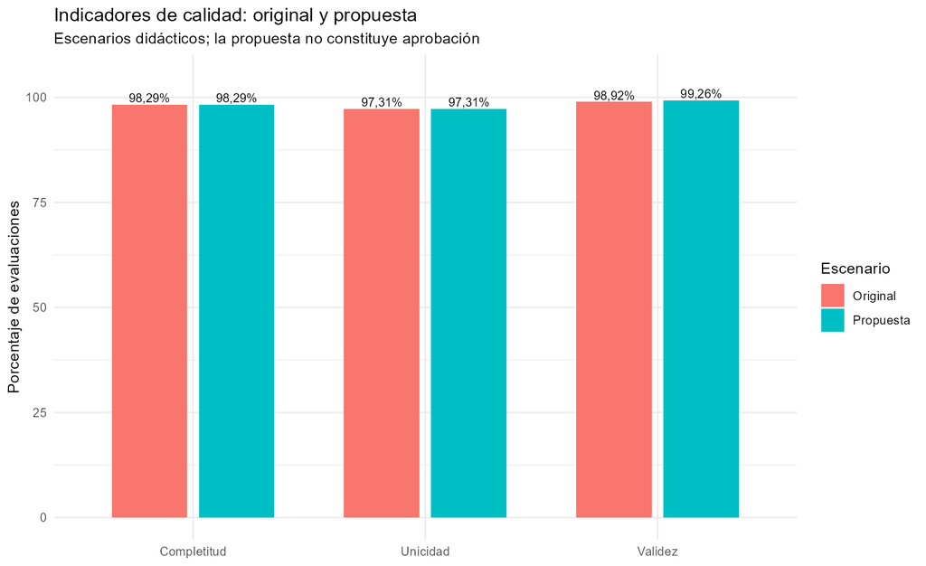

Indicadores de calidad en dos escenarios didácticos

# 4 Resumen estadístico exploratorio

En esta sección se resumen edad e ingreso. Los cálculos utilizan únicamente observaciones interpretables que cumplen los criterios didácticos de cada variable; las ausencias, valores no convertibles y fuera de dominio se informan separadamente. Los valores altos de ingreso se conservan para el análisis y no se consideran automáticamente erróneos.

Descriptivos: media, mediana, cuartiles y registros no evaluables

| variable | ausencias_declaradas | no_convertibles | fuera_dominio | validos_estadisticos | ceros | media | mediana | q1 | q3 | maximo |
| --- | --- | --- | --- | --- | --- | --- | --- | --- | --- | --- |
| edad | 66 | 6 | 12 | 1416 | 14 | 48.30 | 49 | 24 | 72.00 | 95 |
| ingreso_mensual_usd | 52 | 0 | 2 | 1446 | 928 | 1017.45 | 0 | 0 | 606.42 | 1000000 |

La diferencia entre media y mediana puede reflejar una distribución asimétrica. Esta tabla sirve para priorizar revisión, no para imputar sin autorización.

# 5 Incidencias y alertas

## 5.1 Alertas por regla

Conteos de eventos de alerta por origen, regla y severidad

| origen | regla_id | severidad | incidencias |
| --- | --- | --- | --- |
| Consistencia lógica | L5-02 | REVISAR | 6 |
| Consistencia lógica | L5-03 | REVISAR | 8 |
| Integridad | I5-01 | REVISAR | 14 |
| Integridad | I5-02 | REVISAR | 18 |
| Integridad | I5-03 | REVISAR | 40 |

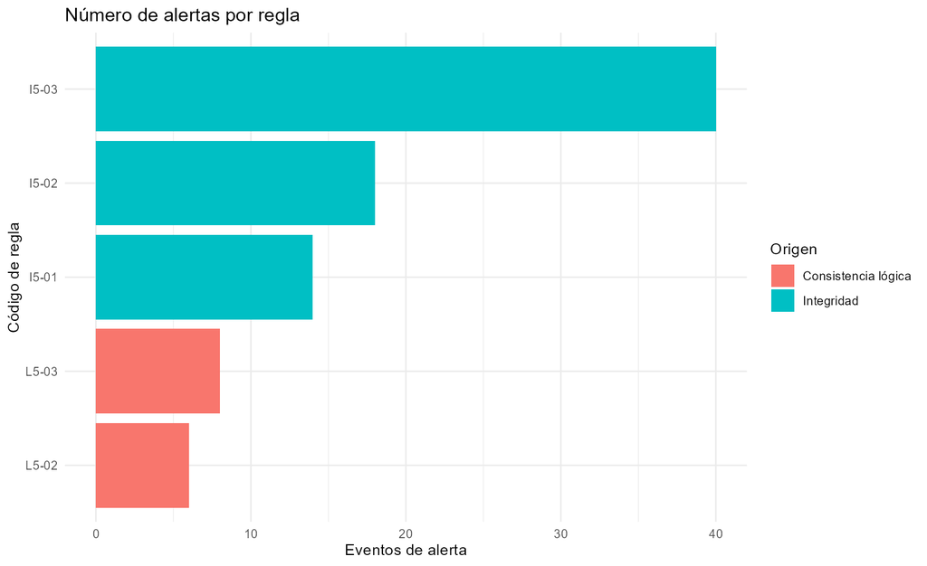

Eventos de alerta por regla; varias reglas pueden afectar una fila

La clasificación `REVISAR` es una etiqueta didáctica, no una decisión técnica definitiva. Antes de utilizar un hallazgo como error confirmado debe verificarse la documentación metodológica y, cuando corresponda, el catálogo de referencia.

## 5.2 Ausencias en campos requeridos

Ausencias sobre campos requeridos del ejercicio

| variable | ausencias | evaluados | porcentaje |
| --- | --- | --- | --- |
| id_persona | 15 | 1500 | 1.00 |
| id_hogar | 18 | 1500 | 1.20 |
| provincia | 33 | 1500 | 2.20 |
| edad | 66 | 1500 | 4.40 |
| fecha_levantamiento | 22 | 1500 | 1.47 |
| personas_hogar | 0 | 1500 | 0.00 |

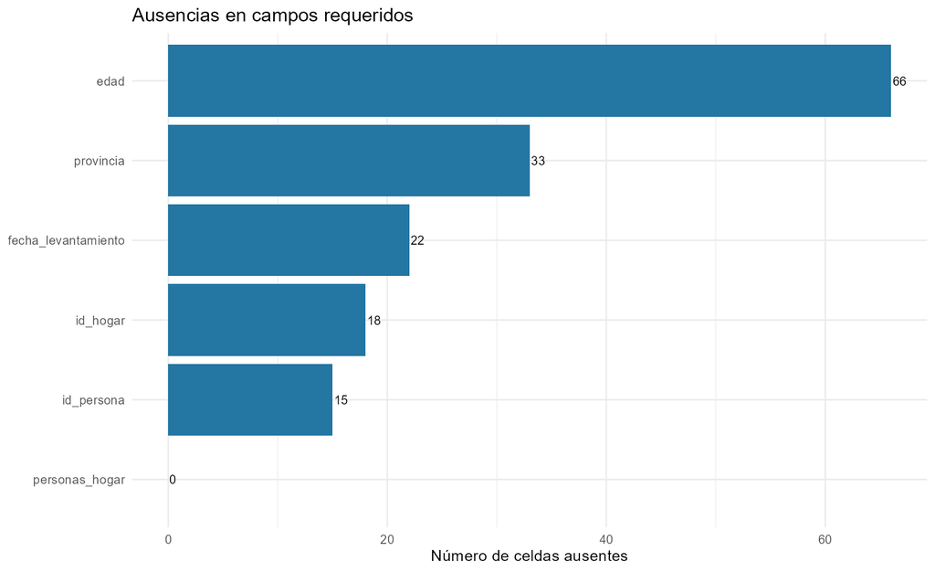

Valores ausentes por campo, sin imputación automática

# 6 Trazabilidad de propuestas de modificación

Resumen de cambios propuestos, por variable y estado

| variable | estado | cambios_propuestos |
| --- | --- | --- |
| provincia | PENDIENTE_DE_APROBACION | 22 |
| area | PENDIENTE_DE_APROBACION | 14 |
| sexo | PENDIENTE_DE_APROBACION | 14 |

La propuesta se conserva como un escenario separado. No se presenta como una base corregida ni se modifican los registros de origen.

# 7 Interpretación técnica y conclusiones

- **Completitud**: no cambió (variación absoluta: 0,00 pp).
- **Validez**: aumentó (variación absoluta: 0,34 pp).
- **Unicidad**: no cambió (variación absoluta: 0,00 pp).

Las variaciones calculadas describen el escenario propuesto, pero **no validan por sí mismas** que una intervención sea correcta. Las diferencias entre archivos o períodos posteriores requieren verificar comparabilidad de población, procedimientos, codificaciones, reglas y denominadores.

# 8 Recomendaciones de aseguramiento

1. Conservar los CSV originales y la versión del diccionario de datos.
2. Revisar con el área responsable las reglas y categorías detectadas.
3. Mantener la bitácora de propuestas y documentar autorizaciones reales antes de corregir.
4. Reejecutar el proceso al recibir un nuevo archivo y comparar solamente indicadores metodológicamente equivalentes.
5. Verificar las cifras y gráficos en HTML y Word antes de compartir el informe.

*Material educativo desarrollado con datos sintéticos. No constituye una publicación estadística oficial del INEC.*